# Country-Specific Geopolitical Risk Index

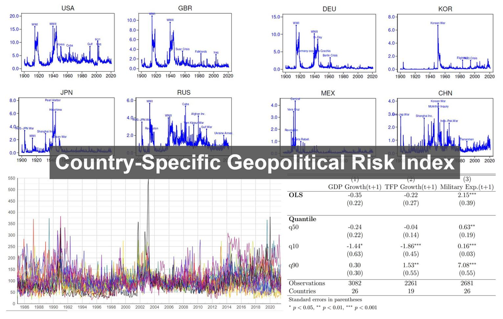

## **Overview**

#### The country-specific GPR indexes are based on searches of newspaper archives. For 44 advanced and emerging countries, Caldara and Iacoviello calculate the country-specific index by counting the monthly share of all newspaper articles from 1900 to present (or 1985 to present for the Recent Index) that both (1) meet the criterion for inclusion in the GPR index and (2) mention the name of the country or its major cities. Each index is expressed as a monthly share of newspaper articles. The resulting indices capture the U.S. perspective on risks posed by, or involving, the country in question. Visit our main GPR index page for additional details.

#### Cite as: Caldara, Dario and Matteo Iacoviello (2022), “Measuring Geopolitical Risk,” American Economic Review, April, 112(4), pp.1194-1225. (This paper uses country-specific indexes for 26 countries.)

#### Caldara, Dario, Sarah Conlisk, Matteo Iacoviello, and Maddie Penn, “Do Geopolitical Risks Raise or Lower Inflation?,” February 2023 (This paper extends the construction of the country-specific indexes to 44 countries.)

##### (When using the data, we suggest referring to both the website and the date of download; e.g. “Data downloaded from https://www.matteoiacoviello.com/gpr.htm on Month DD, YYYY”).

#### Plots and narrative information for each individual country are available clicking the links below.

#### North America: Canada, Mexico, USA South America: Argentina, Brazil, Chile, Colombia, Peru, Venezuela Europe (North and East): Denmark, Finland, Hungary, Norway, Poland, Russia, Sweden, Ukraine, United Kingdom Europe (South and West): Belgium, France, Germany, Italy, The Netherlands, Portugal, Spain, Switzerland Middle East and Africa: Egypt, Israel, Saudi Arabia, South Africa, Tunisia, Turkey Asia and Oceania: Australia, China, Hong Kong, Japan, South Korea, The Philippines, Taiwan, Indonesia, India, Malaysia, Thailand, Vietnam

## **Data**

#### Download our monthly data here: Excel format; Stata format The monthly data are updated at the beginning of each month.* (Last update: October 1, 2026). The monthly data include the country-specific GPR indexes. Each series mnemonics is described in the last columns of the Excel file and in the Stata file.

#### Daily data for the Recent GPR index are available here: Excel format; Stata format *The daily data are updated every Monday.* (Last update: October 26, 2026)*

##### *If the first day of the month or week falls on a federal holiday, data updates will take place the next business day.

#### Access older vintages of the data [here](https://github.com/iacoviel/iacoviel.github.io/tree/master/gpr_archive_files).

###### Monthly vintages are named as follows, where YYYYMM are the year and month of the update version: Excel format: data_gpr_export_YYYYMM.xls Stata format: data_gpr_export_YYYYMM.dta Daily vintages are named as follows, where YYYYMMDD are the year, month, and day of the update version: Excel format: data_gpr_daily_recent_YYYYMMDD.xls Stata format: data_gpr_daily_recent_YYYYMMDD.dta Note: The latest data are preliminary and subject to revisions since some newspapers are added to the search database with delay. Additionally, in some cases there could be minor revisions of the data extending further back when duplicate or missing articles or newspaper editions are removed from or added to the database.

## **Charts of Country-Specific GPR Indexes**

- Recent Index
- Historical Index
- Country-Level Averages

[interactive chart not shown]

Note: Move the slider below the chart to zoom in on a specific date range. Click and drag a square around any area to zoom in further. Double click the chart to zoom back out. Select or deselect individual countries to compare their GPR indexes. Double click to isolate one series and again to select all series.

License: All the material in this webpage, including interactive visualizations and code, are completely open access under the [Creative Commons BY license](https://creativecommons.org/licenses/by/4.0/). You have the permission to use, distribute, and reproduce these in any medium, provided the source and authors are credited.  
This webpage is maintained by Lilliana Wells, Will Yang, Sam Nate, and Matteo Iacoviello.